# Manuscript Report: Low N Sedimentary Site 80_BO

### Cation Exchange Capacity

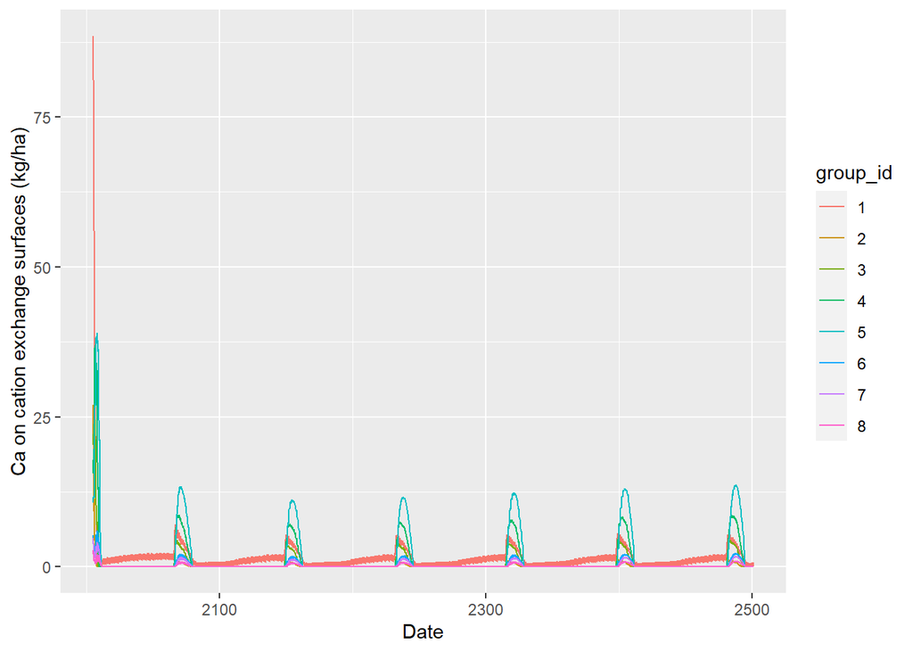

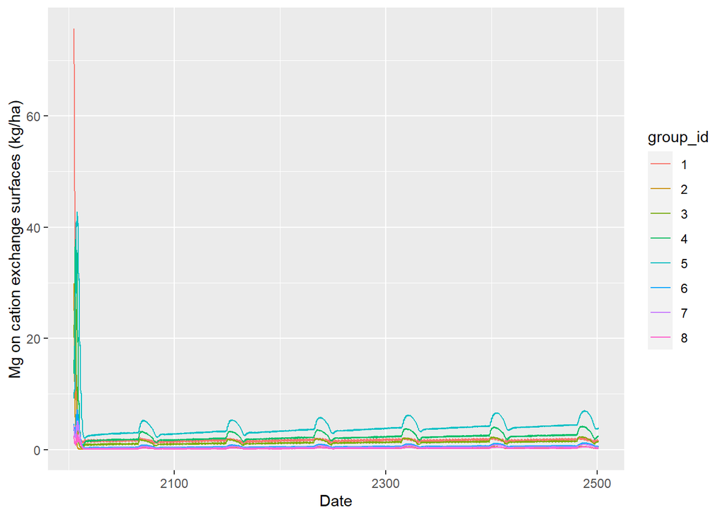

Calcium and Magnesium on exchangerover time

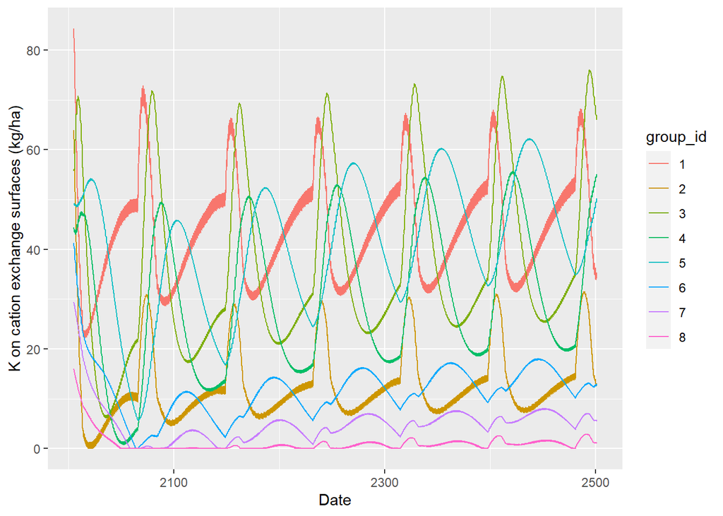

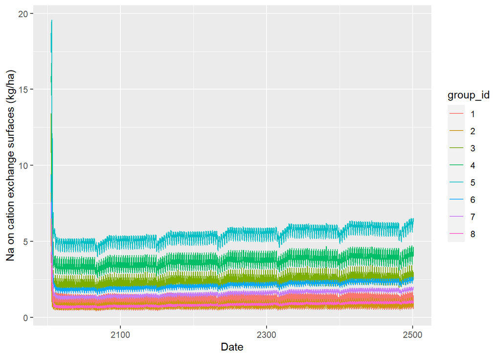

Potassium and Sodium on exchangerover time

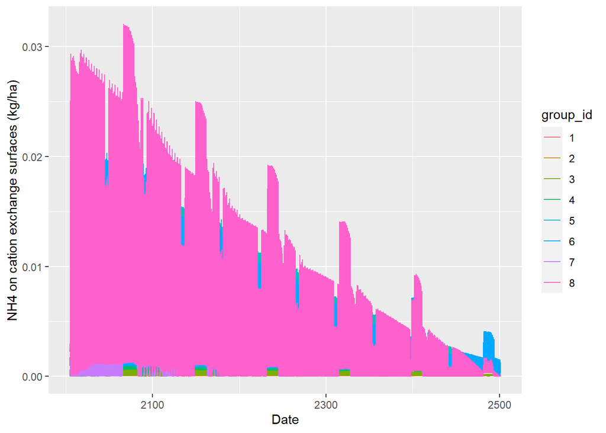

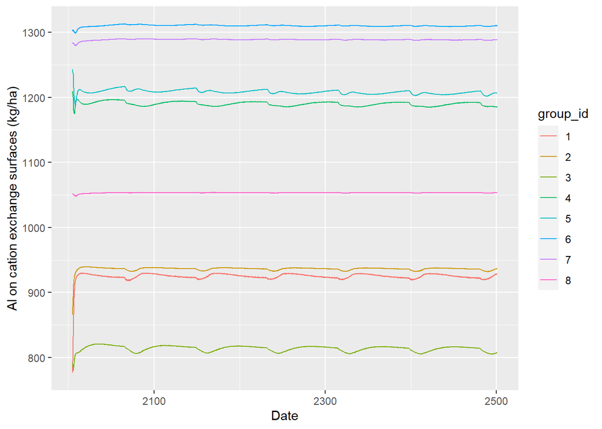

Ammonium and Aluminum on exchangerover time

### Anion Exchange Capacity

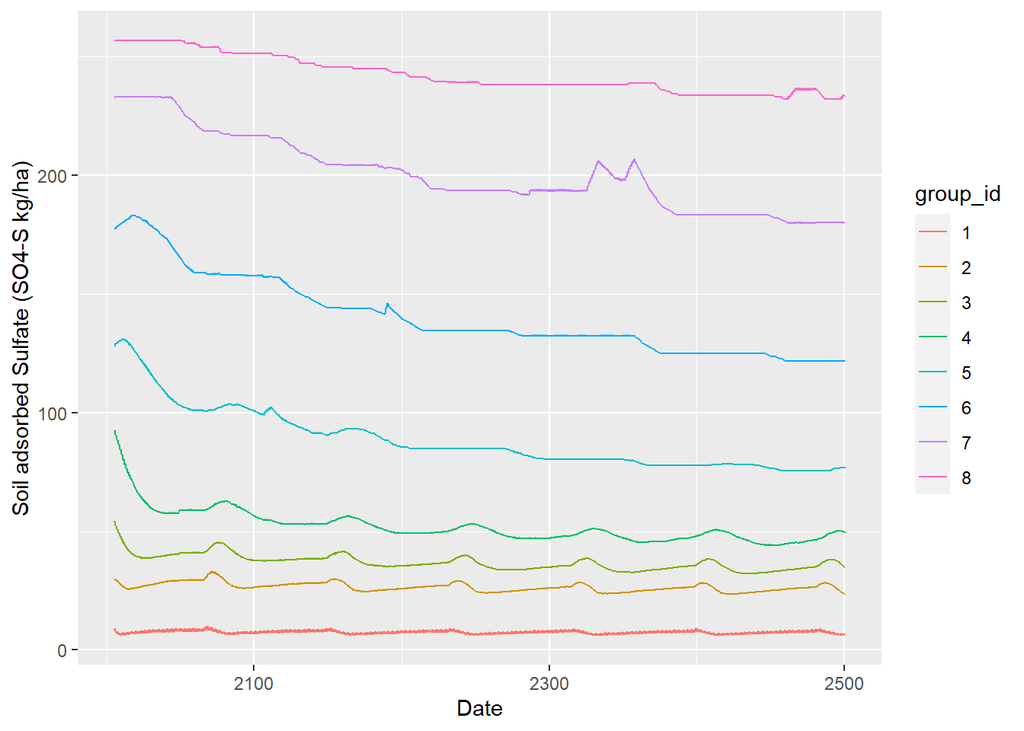

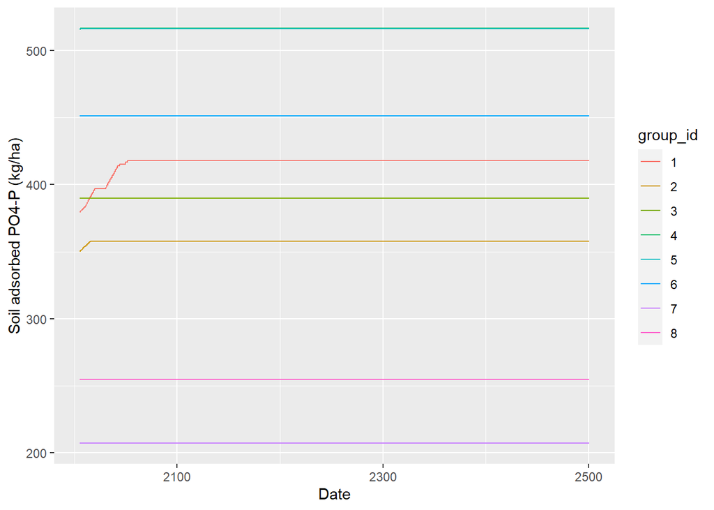

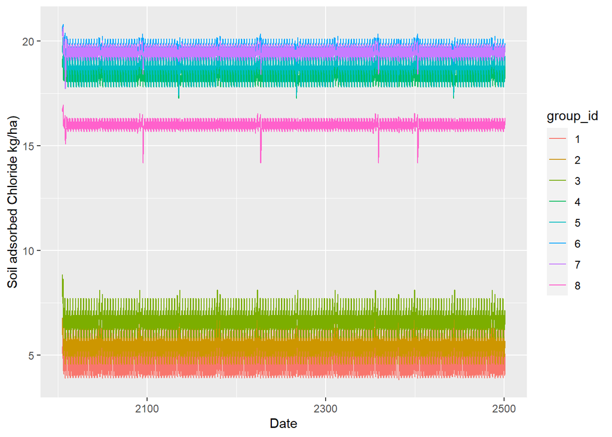

The phosphate adsorption is set from the original parameterization I received from Gregory. It tends to build up, which implies a high soil solution concentration (adsorption is determined by concentration).

Sulfate adsorption is weak and drains easily, I set a low adsorbed sulfate pool following IFS data from the Thompson site (glacial outwash, inceptisol). According to the book *Atmospheric Sulfur Deposition: Environmental and Health Impacts*, sulfur is mostly locked in organic compartments rather than on the adsorption surfaces. We might expect that sulfate, like phosphate, would increase on the AEC, however the input of sulfate relative to the adsorption and uptake of sulfate is likely too low to facilitate adsorption. This is well supported by IFS data that show low sulfate adsorption on potentially high capacity adsorbing soils. The higher sulfate concentrations observed at the high N site could well be due to a higher inherent sulfur pool, possibly a condition of higher sulfate-mineral weathering, or due to a competitive response with phosphate.

### Other

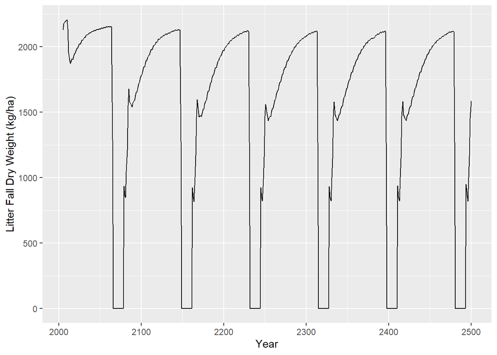

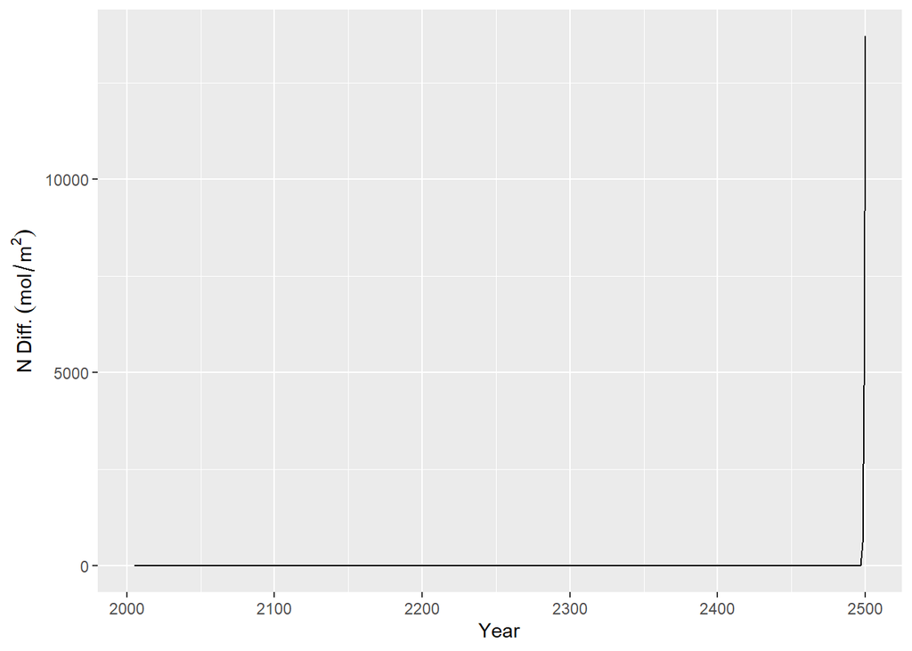

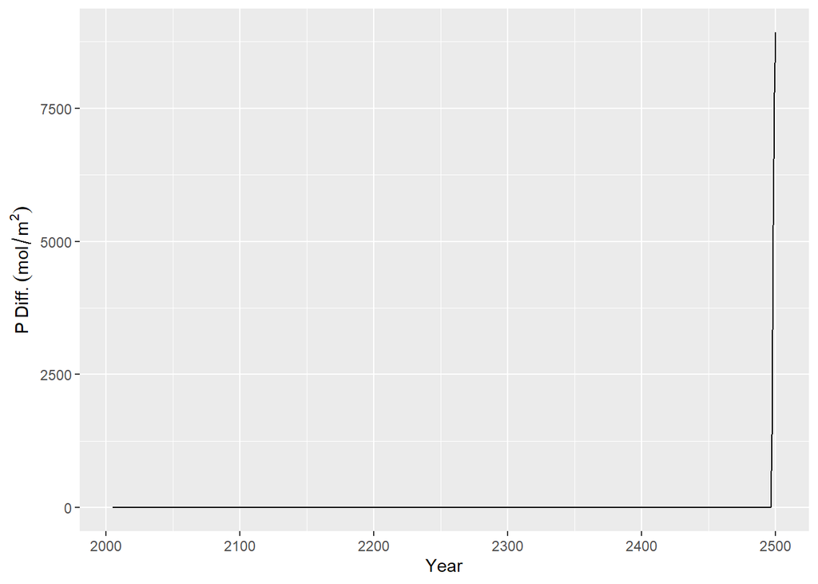

N and P Potential Uptake to Actual Uptake Difference

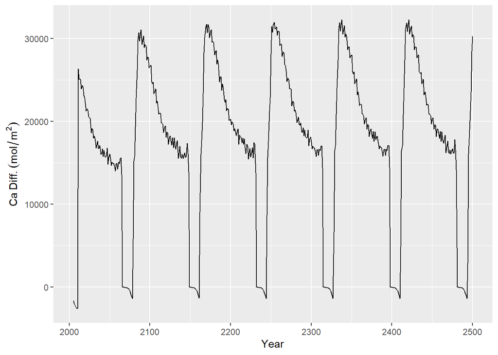

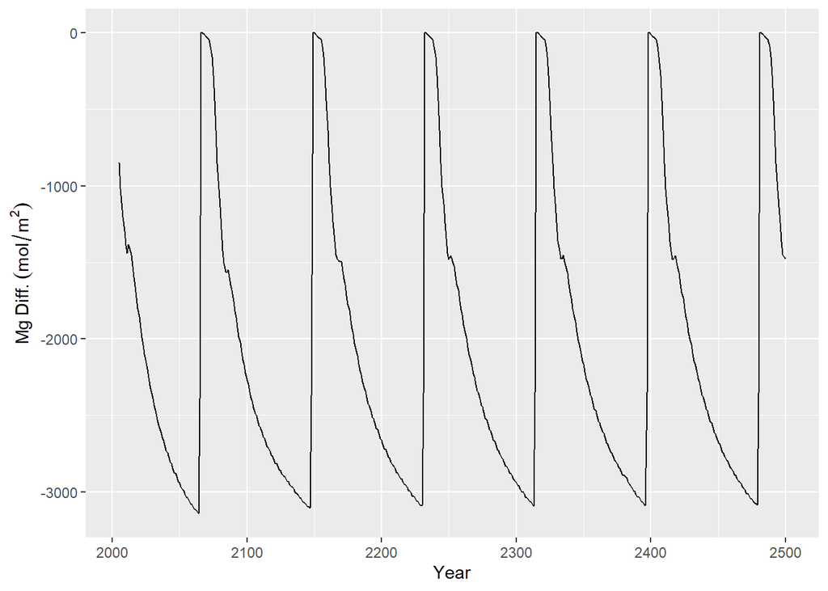

Ca and Mg Potential Uptake to Actual Uptake Difference

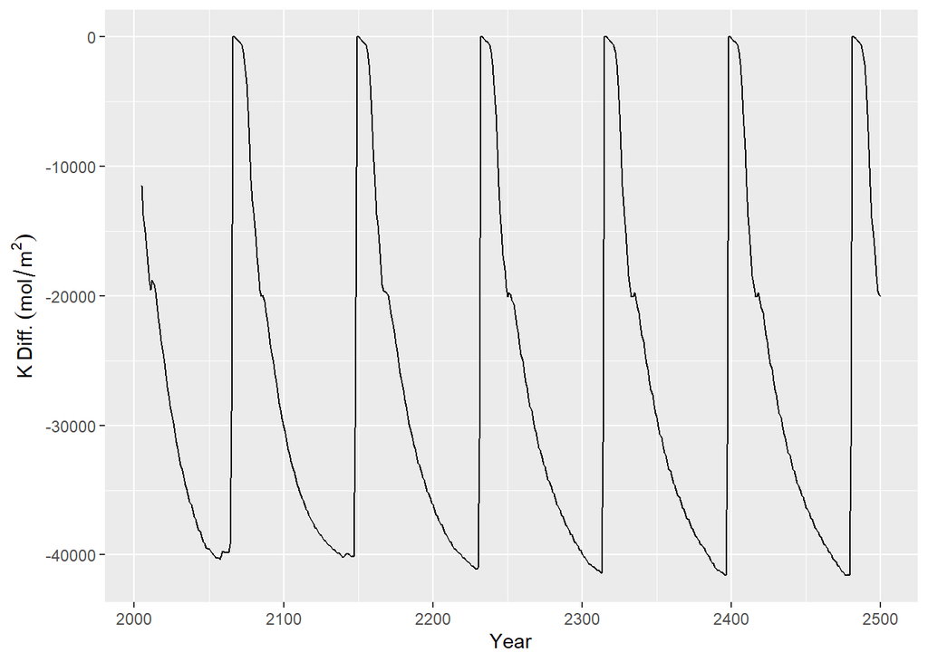

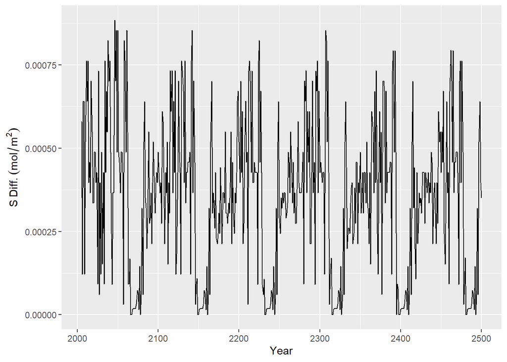

K and S Potential Uptake to Actual Uptake Difference